# R Final Project

Anthony Pagan

July 28, 2018

## R Final Project

#### The state data provided in this project gives information on public school spending per student and teachers, as well as graduation rates and reading and math scores. The analysis trys to answer the following question:

#### *Does an increase in State spending in education increase student graduation rates and/or scores on standardize tests?*

### Loading local State Data

```r
setwd("C://users//apagan//Documents//MSDSBridge//R//datasets")
stdt <- read.csv("States.csv", sep=",")
```

### BONUS: LOAD DATA FROM GITHUB

```r
theurl <-"https://raw.githubusercontent.com/apag101/MSDSBridge/master/States.csv"
stdtgh <- read.table(file = theurl, header = TRUE, sep = ",")
head(stdtgh)
```

```
##    X region   pop SATV SATM percent dollars pay
## 1 AL    ESC  4041  470  514       8   3.648  27
## 2 AK    PAC   550  438  476      42   7.887  43
## 3 AZ    MTN  3665  445  497      25   4.231  30
## 4 AR    WSC  2351  470  511       6   3.334  23
## 5 CA    PAC 29760  419  484      45   4.826  39
## 6 CO    MTN  3294  456  513      28   4.809  31
```

### Update Column Names

```r
names(stdt)
```

```
## [1] "X"       "region"  "pop"     "SATV"    "SATM"    "percent" "dollars"
## [8] "pay"
```

```r
names(stdt) <-c("State","Region","Population","Verbal","Math", "%Grad", "EduSpend1000s", "AvgPay1000s")
names(stdt)
```

```
## [1] "State"         "Region"        "Population"    "Verbal"
## [5] "Math"          "%Grad"         "EduSpend1000s" "AvgPay1000s"
```

### Added a caculated column Per Student Education Spending as a percentage of Teacher Salary

```r
stdtt<-cbind(stdt$EduSpend1000s/stdt$AvgPay1000s)
colnames(stdtt)<- c("StdInvPerTeachPay")
stdt <-cbind(stdt,stdtt)
head(stdt)
```

```
##   State Region Population Verbal Math %Grad EduSpend1000s AvgPay1000s
## 1    AL    ESC       4041    470  514     8         3.648          27
## 2    AK    PAC        550    438  476    42         7.887          43
## 3    AZ    MTN       3665    445  497    25         4.231          30
## 4    AR    WSC       2351    470  511     6         3.334          23
## 5    CA    PAC      29760    419  484    45         4.826          39
## 6    CO    MTN       3294    456  513    28         4.809          31
##   StdInvPerTeachPay
## 1         0.1351111
## 2         0.1834186
## 3         0.1410333
## 4         0.1449565
## 5         0.1237436
## 6         0.1551290
```

### Summary of Data, Min/Max/Median/Quartile per column

```r
summary(stdt)
```

```
##      State        Region     Population        Verbal           Math
##  AK     : 1   SA     : 9   Min.   :  454   Min.   :397.0   Min.   :437.0
##  AL     : 1   MTN    : 8   1st Qu.: 1215   1st Qu.:422.5   1st Qu.:470.0
##  AR     : 1   WNC    : 7   Median : 3294   Median :443.0   Median :490.0
##  AZ     : 1   NE     : 6   Mean   : 4877   Mean   :448.2   Mean   :497.4
##  CA     : 1   ENC    : 5   3rd Qu.: 5780   3rd Qu.:474.5   3rd Qu.:522.5
##  CN     : 1   PAC    : 5   Max.   :29760   Max.   :511.0   Max.   :577.0
##  (Other):45   (Other):11
##      %Grad       EduSpend1000s    AvgPay1000s    StdInvPerTeachPay
##  Min.   : 4.00   Min.   :2.993   Min.   :22.00   Min.   :0.1197
##  1st Qu.:11.50   1st Qu.:4.354   1st Qu.:27.50   1st Qu.:0.1521
##  Median :25.00   Median :5.045   Median :30.00   Median :0.1656
##  Mean   :33.75   Mean   :5.175   Mean   :30.94   Mean   :0.1659
##  3rd Qu.:57.50   3rd Qu.:5.689   3rd Qu.:33.50   3rd Qu.:0.1789
##  Max.   :74.00   Max.   :9.159   Max.   :43.00   Max.   :0.2410
##
```

### Plotted Data

##### Plotting an aggregated mean of Teacher pay and the Education Spending to the Percent graduation rate shows a positive correlation. This could hint that investment in schools and teachers can result in higher graduation rates.

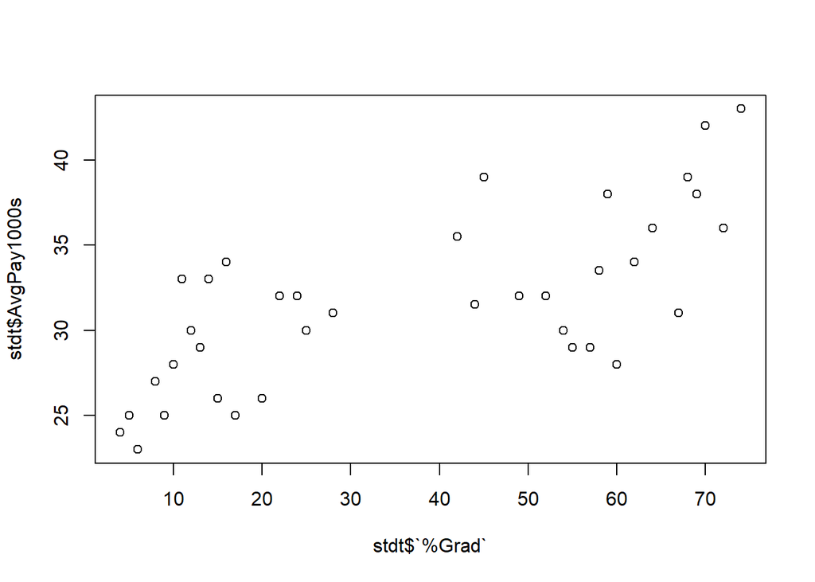

```r
plot(aggregate (stdt$AvgPay1000s~ stdt$`%Grad`, stdt, mean))
```

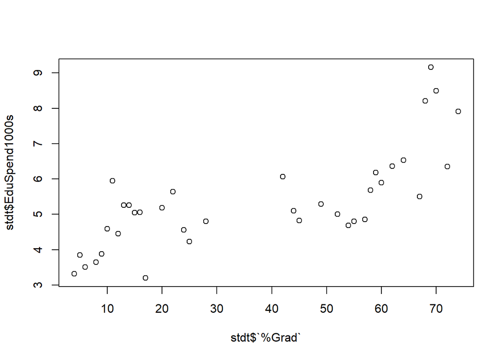

```r
plot(aggregate (stdt$EduSpend1000s~ stdt$`%Grad`, stdt, mean))
```

##### However, the Verbal and Math scores vs the Education/Teacher investments are negatively correlated.

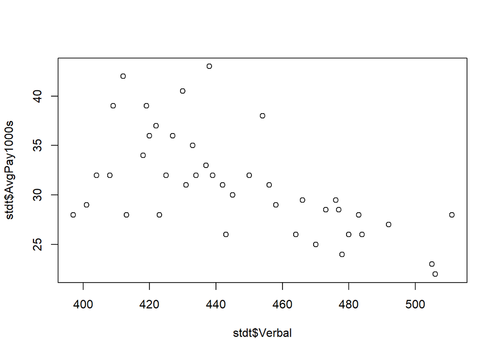

```r
plot(aggregate (stdt$AvgPay1000s~ stdt$Verbal, stdt, mean))
```

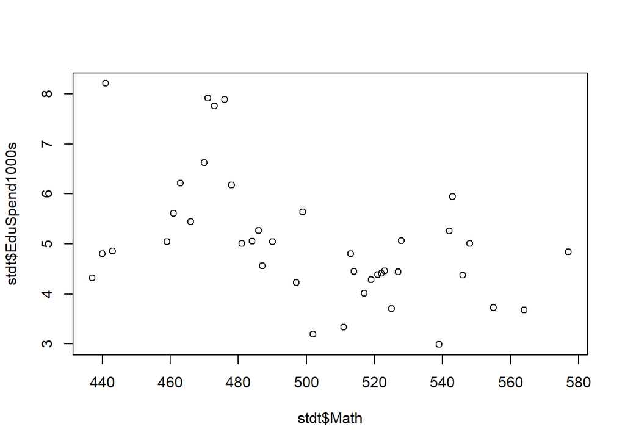

```r
plot(aggregate (stdt$EduSpend1000s~ stdt$Math, stdt, mean))
```

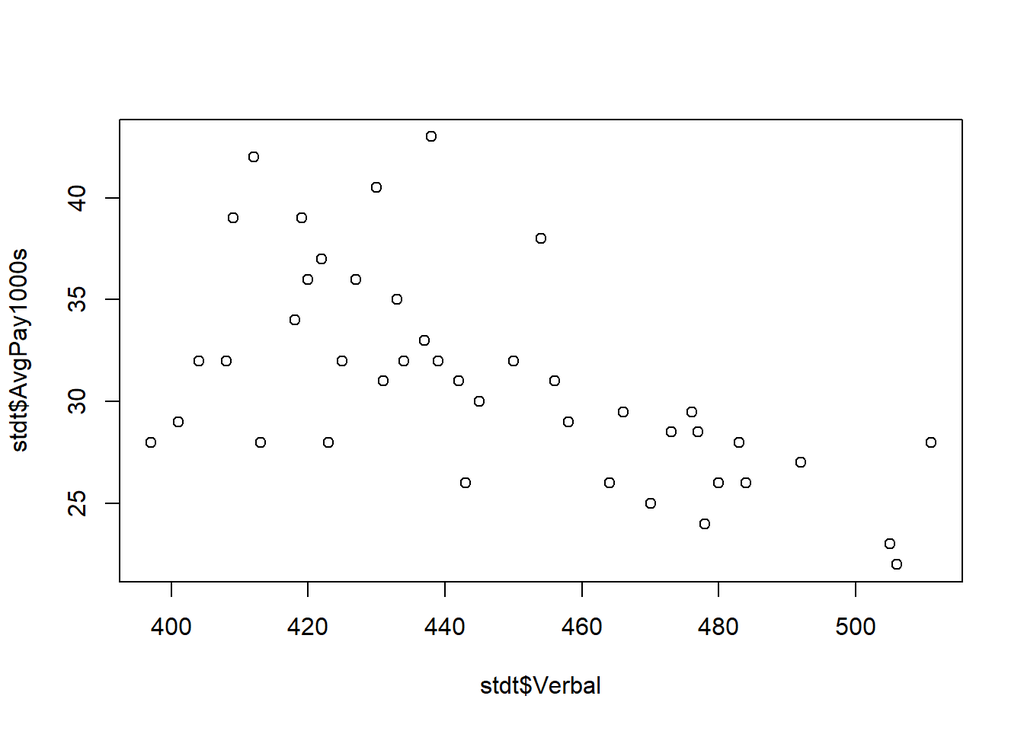

```r
plot(aggregate (stdt$AvgPay1000s~ stdt$Verbal, stdt, mean))
```

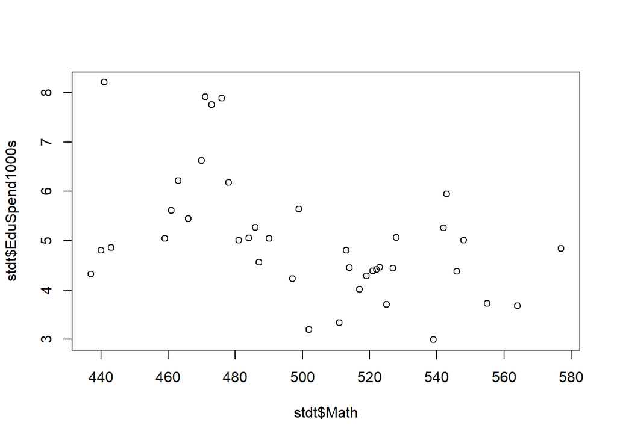

```r
plot(aggregate (stdt$EduSpend1000s~ stdt$Math, stdt, mean))
```

##### A histogram chart of Average Teacher Pay and Education Spending are positively skewed although Graduation rates are bimodal

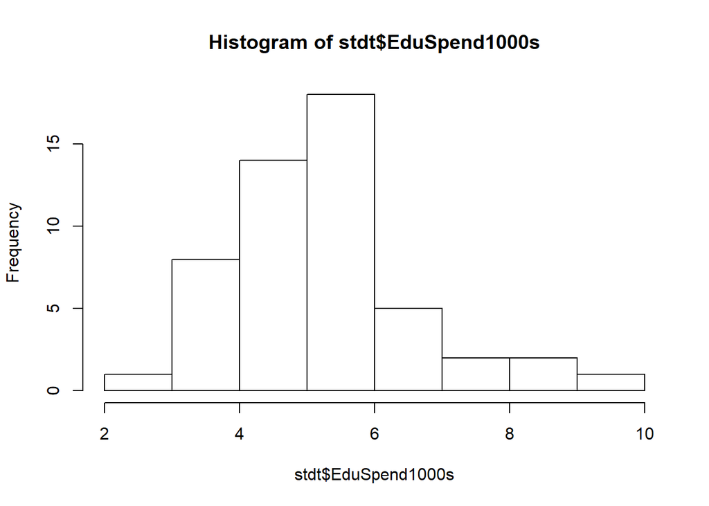

```r
hist(stdt$EduSpend1000s)
```

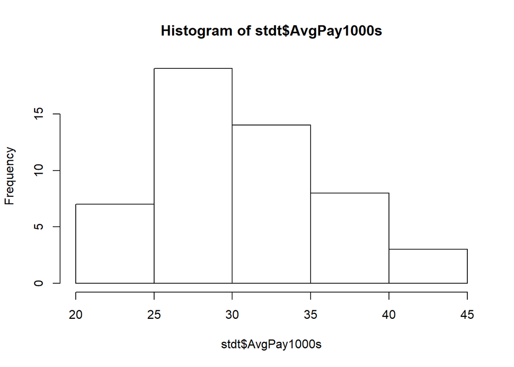

```r
hist(stdt$AvgPay1000s)
```

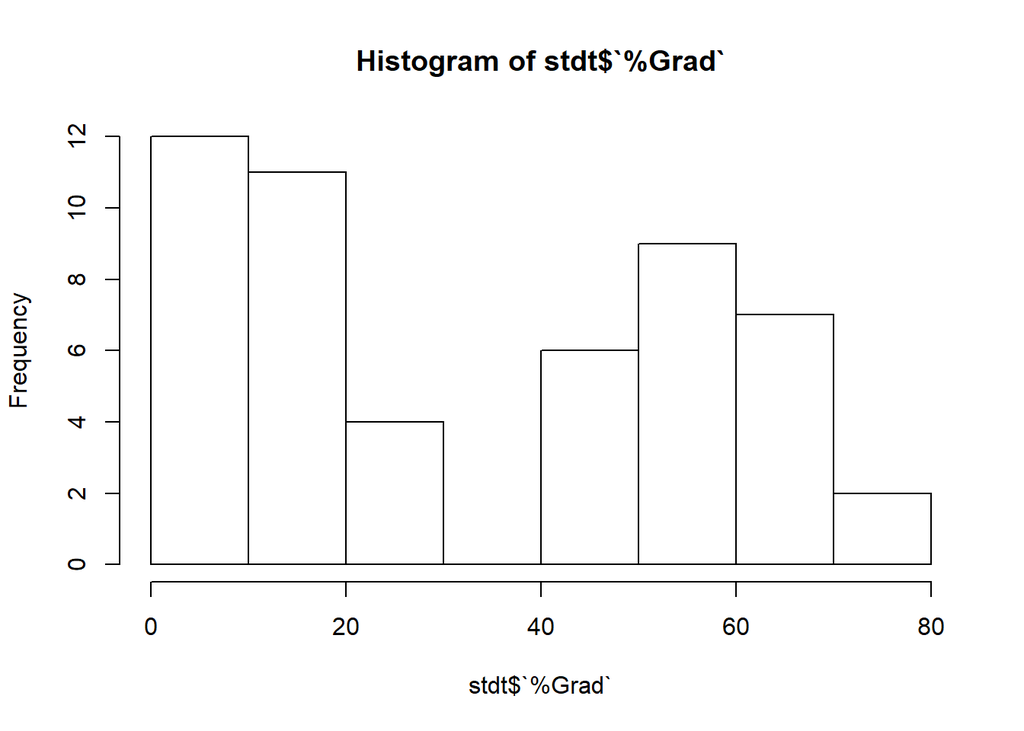

```r
hist(stdt$`%Grad`)
```

#### Below are the State/Regions who have above average in Education Spending, Teacher Pay and Graduation rate. The bulk of the above average Grad rates as compared to increase in budgets are in the NE and SA Regions.

```r
subset(stdt, `%Grad`>mean(`%Grad`) & EduSpend1000s > mean(EduSpend1000s) & AvgPay1000s > mean(AvgPay1000s), select = c(State, Region, `%Grad`, EduSpend1000s, AvgPay1000s, Math, Verbal))
```

```
##    State Region %Grad EduSpend1000s AvgPay1000s Math Verbal
## 2     AK    PAC    42         7.887          43  476    438
## 7     CN     NE    74         7.914          43  471    430
## 8     DE     SA    58         6.016          35  470    433
## 9     DC     SA    68         8.210          39  441    409
## 21    MD     SA    59         6.184          38  478    430
## 22    MA     NE    72         6.351          36  473    427
## 30    NH     NE    67         5.504          31  486    442
## 31    NJ     MA    69         9.159          38  473    418
## 33    NY     MA    70         8.500          42  470    412
## 38    OR    PAC    49         5.291          32  484    439
## 39    PA     MA    64         6.534          36  463    420
## 40    RI     NE    62         6.989          37  461    422
## 46    VT     NE    62         5.740          31  466    431
## 47    VA     SA    58         5.360          32  470    425
```

```r
stdt.stats <- rbind(min(stdt$EduSpend1000s), min(stdt$AvgPay1000s),min(stdt$Math),min(stdt$Verbal), min(stdt$`%Grad`),mean(stdt$EduSpend1000s), mean(stdt$AvgPay1000s),mean(stdt$Math),mean(stdt$Verbal), mean(stdt$`%Grad`),max(stdt$EduSpend1000s), max(stdt$AvgPay1000s),max(stdt$Math),max(stdt$Verbal), max(stdt$`%Grad`))
rownames(stdt.stats)<-c("MinEduSpend","MinAvgPay","MinMath","MinVerbal","MinGrads","MeanEduSpend","MeanAvgPay","MeanMath","MeanVerbal","MeanGrads","MaxEduSpend","MaxAvgPay","MaxMath","MaxVerbal","MaxGrads")
stdt.stats
```

```
##                   [,1]
## MinEduSpend    2.99300
## MinAvgPay     22.00000
## MinMath      437.00000
## MinVerbal    397.00000
## MinGrads       4.00000
## MeanEduSpend   5.17549
## MeanAvgPay    30.94118
## MeanMath     497.39216
## MeanVerbal   448.15686
## MeanGrads     33.74510
## MaxEduSpend    9.15900
## MaxAvgPay     43.00000
## MaxMath      577.00000
## MaxVerbal    511.00000
## MaxGrads      74.00000
```

### Summary

#### In summary, this analysis tells us students in this sample data do well enough in school to graduate, but additional investment in schools/teachers do not increase scores in standardize SAT tests. Are schools revamping their curriculum enough to cover SAT material when State spending in public education is increased? This data hints that the answer to that question is negative.

### Data Reference Links

[DOC] http://vincentarelbundock.github.io/Rdatasets/doc/carData/States.html

[DataSet] http://vincentarelbundock.github.io/Rdatasets/csv/carData/States.csv